# 12 - Generalized Estimation Equations and Special Distributions

Francisco E. Fonturbel

31/October/2025

# Relaxing Model Assumptions Even Further

Generalized Linear Models relax some assumptions (e.g., a normal distribution) and allow us to use count data or presence/absence data instead. In this opportunity, we will go beyond and relax other assumptions to properly analyze real life data.

## The Challenge with Real-World Data

Real ecological and biological data often violate standard GLM assumptions in two major ways:

1. **Excess zeros:** Many datasets have more zeros than expected by standard distributions
2. **Correlated observations:** Repeated measures or clustered data violate independence

### When Standard GLMs Fail

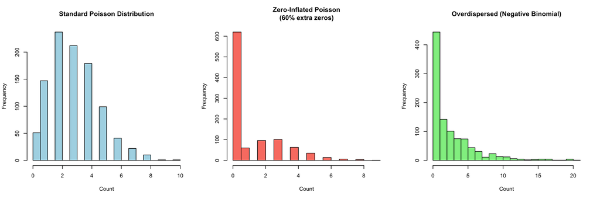

```r
set.seed(123)
par(mfrow=c(1,3))

# 1. Normal Poisson
x_pois <- rpois(1000, lambda=3)
hist(x_pois, main="Standard Poisson Distribution",
     xlab="Count", col="lightblue", breaks=20)

# 2. Zero-inflated Poisson
x_zip <- c(rep(0, 600), rpois(400, lambda=3))
hist(x_zip, main="Zero-Inflated Poisson\n(60% extra zeros)",
     xlab="Count", col="salmon", breaks=20)

# 3. Overdispersed data
x_nb <- rnegbin(1000, mu=3, theta=1)
hist(x_nb, main="Overdispersed (Negative Binomial)",
     xlab="Count", col="lightgreen", breaks=20)
```

```r
par(mfrow=c(1,1))
```

**In this lesson we will:** 1. Compare regular GLMs with their zero-inflated alternatives 2. Use Generalized Estimation Equations (GEE) that relax the independence assumption 3. Learn how to diagnose and handle these data challenges

## Zero-Inflated Distributions

These are a special version of Poisson and negative binomial distributions in which we have an excess of zeros creating a deviation towards zero in the observed distribution. In many biological systems we face this problem, as capture/record events are rare. For example, when we set traps for capturing a given animal, in most cases the trapping success is lower than 20%. Thus, we will have a lot of zeros in our data, and therefore the conclusions from our GLM models may not be entirely reliable.

### Understanding Zero-Inflation

**Why do we get excess zeros?** - **Structural zeros:** The event cannot occur (e.g., infertile individuals cannot reproduce) - **Sampling zeros:** The event could occur but didn’t during observation period - **Detection zeros:** The event occurred but wasn’t detected

**Zero-inflated models account for two processes:** 1. **Zero-inflation process:** Binary process determining if zero or non-zero 2. **Count process:** Standard count distribution (Poisson or Negative Binomial) for non-zeros

### Example Data: Biochemist Publications

In the past session we introduced different data distributions, but now we’ll see zero-inflated models in action. To illustrate this we will use the *bioChemists* dataset included in the `pscl` package, which contains publication counts for PhD biochemists.

```r
data("bioChemists", package = "pscl")

# Examine data structure
str(bioChemists)
```

```
## 'data.frame':    915 obs. of  6 variables:
##  $ art : int  0 0 0 0 0 0 0 0 0 0 ...
##  $ fem : Factor w/ 2 levels "Men","Women": 1 2 2 1 2 2 2 1 1 2 ...
##  $ mar : Factor w/ 2 levels "Single","Married": 2 1 1 2 1 2 1 2 1 2 ...
##  $ kid5: num  0 0 0 1 0 2 0 2 0 0 ...
##  $ phd : num  2.52 2.05 3.75 1.18 3.75 ...
##  $ ment: int  7 6 6 3 26 2 3 4 6 0 ...
##  - attr(*, "datalabel")= chr "Academic Biochemists / S Long"
##  - attr(*, "time.stamp")= chr "30 Jan 2001 10:49"
##  - attr(*, "formats")= chr [1:6] "%9.0g" "%9.0g" "%9.0g" "%9.0g" ...
##  - attr(*, "types")= int [1:6] 98 98 98 98 102 98
##  - attr(*, "val.labels")= chr [1:6] "" "sexlbl" "marlbl" "" ...
##  - attr(*, "var.labels")= chr [1:6] "Articles in last 3 yrs of PhD" "Gender: 1=female 0=male" "Married: 1=yes 0=no" "Number of children < 6" ...
##  - attr(*, "version")= int 6
##  - attr(*, "label.table")=List of 6
##   ..$ marlbl: Named num [1:2] 0 1
##   .. ..- attr(*, "names")= chr [1:2] "Single" "Married"
##   ..$ sexlbl: Named num [1:2] 0 1
##   .. ..- attr(*, "names")= chr [1:2] "Men" "Women"
##   ..$       : NULL
##   ..$       : NULL
##   ..$       : NULL
##   ..$       : NULL
```

```r
head(bioChemists, 10)
```

```
##    art   fem     mar kid5  phd ment
## 1    0   Men Married    0 2.52    7
## 2    0 Women  Single    0 2.05    6
## 3    0 Women  Single    0 3.75    6
## 4    0   Men Married    1 1.18    3
## 5    0 Women  Single    0 3.75   26
## 6    0 Women Married    2 3.59    2
## 7    0 Women  Single    0 3.19    3
## 8    0   Men Married    2 2.96    4
## 9    0   Men  Single    0 4.62    6
## 10   0 Women Married    0 1.25    0
```

```r
# Summary statistics
summary(bioChemists)
```

```
##       art            fem           mar           kid5             phd
##  Min.   : 0.000   Men  :494   Single :309   Min.   :0.0000   Min.   :0.755
##  1st Qu.: 0.000   Women:421   Married:606   1st Qu.:0.0000   1st Qu.:2.260
##  Median : 1.000                             Median :0.0000   Median :3.150
##  Mean   : 1.693                             Mean   :0.4951   Mean   :3.103
##  3rd Qu.: 2.000                             3rd Qu.:1.0000   3rd Qu.:3.920
##  Max.   :19.000                             Max.   :3.0000   Max.   :4.620
##       ment
##  Min.   : 0.000
##  1st Qu.: 3.000
##  Median : 6.000
##  Mean   : 8.767
##  3rd Qu.:12.000
##  Max.   :77.000
```

### Exploratory Data Analysis

```r
# Check for zero-inflation
n_zeros <- sum(bioChemists$art == 0)
n_total <- nrow(bioChemists)
prop_zeros <- n_zeros / n_total

print(paste("Number of zeros:", n_zeros, "out of", n_total))
```

```
## [1] "Number of zeros: 275 out of 915"
```

```r
print(paste("Proportion of zeros:", round(prop_zeros, 3)))
```

```
## [1] "Proportion of zeros: 0.301"
```

```r
# What would Poisson predict?
mean_art <- mean(bioChemists$art)
expected_zeros_poisson <- dpois(0, lambda = mean_art) * n_total
print(paste("Expected zeros under Poisson:", round(expected_zeros_poisson, 1)))
```

```
## [1] "Expected zeros under Poisson: 168.3"
```

```r
print(paste("Observed zeros:", n_zeros))
```

```
## [1] "Observed zeros: 275"
```

```r
print(paste("Excess zeros:", n_zeros - round(expected_zeros_poisson, 1)))
```

```
## [1] "Excess zeros: 106.7"
```

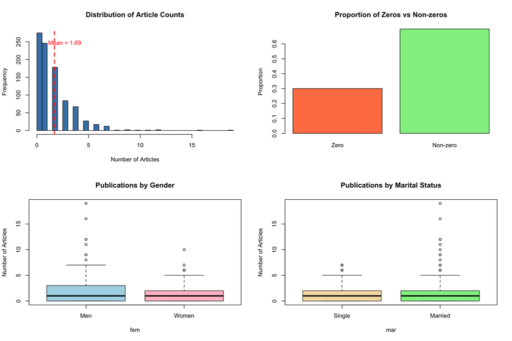

```r
# Visualizations
par(mfrow=c(2,2))

# 1. Distribution of publications
hist(bioChemists$art, breaks=30, col="steelblue",
     main="Distribution of Article Counts",
     xlab="Number of Articles", ylab="Frequency")
abline(v=mean_art, col="red", lwd=2, lty=2)
text(mean_art + 1, max(table(bioChemists$art)) * 0.9,
     paste("Mean =", round(mean_art, 2)), col="red")

# 2. Proportion of zeros
barplot(c(prop_zeros, 1-prop_zeros),
        names.arg=c("Zero", "Non-zero"),
        col=c("coral", "lightgreen"),
        main="Proportion of Zeros vs Non-zeros",
        ylab="Proportion")

# 3. Publications by gender
boxplot(art ~ fem, data=bioChemists,
        col=c("lightblue", "pink"),
        names=c("Men", "Women"),
        main="Publications by Gender",
        ylab="Number of Articles")

# 4. Publications by marital status
boxplot(art ~ mar, data=bioChemists,
        col=c("wheat", "lightgreen"),
        names=c("Single", "Married"),
        main="Publications by Marital Status",
        ylab="Number of Articles")
```

```r
par(mfrow=c(1,1))

# Check variance vs mean
print(paste("Mean:", round(mean(bioChemists$art), 2)))
```

```
## [1] "Mean: 1.69"
```

```r
print(paste("Variance:", round(var(bioChemists$art), 2)))
```

```
## [1] "Variance: 3.71"
```

```r
print(paste("Variance/Mean ratio:", round(var(bioChemists$art)/mean(bioChemists$art), 2)))
```

```
## [1] "Variance/Mean ratio: 2.19"
```

```r
print("Ratio > 1 suggests overdispersion")
```

```
## [1] "Ratio > 1 suggests overdispersion"
```

### Model 1: Standard Poisson GLM

Now, let’s make a regular GLM with this dataset:

```r
model1 <- glm(art ~ ., data = bioChemists, family = poisson)
summary(model1)
```

```
##
## Call:
## glm(formula = art ~ ., family = poisson, data = bioChemists)
##
## Coefficients:
##              Estimate Std. Error z value Pr(>|z|)
## (Intercept)  0.304617   0.102981   2.958   0.0031 **
## femWomen    -0.224594   0.054613  -4.112 3.92e-05 ***
## marMarried   0.155243   0.061374   2.529   0.0114 *
## kid5        -0.184883   0.040127  -4.607 4.08e-06 ***
## phd          0.012823   0.026397   0.486   0.6271
## ment         0.025543   0.002006  12.733  < 2e-16 ***
## ---
## Signif. codes:  0 '***' 0.001 '**' 0.01 '*' 0.05 '.' 0.1 ' ' 1
##
## (Dispersion parameter for poisson family taken to be 1)
##
##     Null deviance: 1817.4  on 914  degrees of freedom
## Residual deviance: 1634.4  on 909  degrees of freedom
## AIC: 3314.1
##
## Number of Fisher Scoring iterations: 5
```

```r
# Check for overdispersion
library(AER)
dispersion_test1 <- dispersiontest(model1)
print(dispersion_test1)
```

```
##
##  Overdispersion test
##
## data:  model1
## z = 5.7825, p-value = 3.681e-09
## alternative hypothesis: true dispersion is greater than 1
## sample estimates:
## dispersion
##    1.82454
```

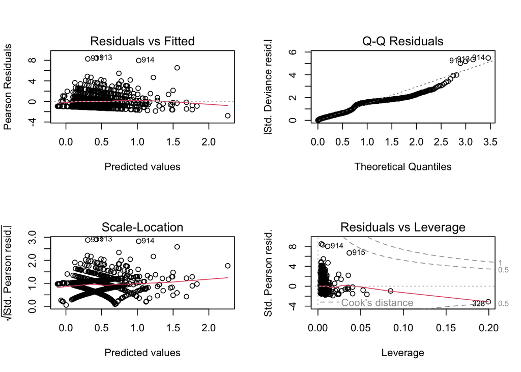

```r
# Residual diagnostics
par(mfrow=c(2,2))
plot(model1)
```

```r
par(mfrow=c(1,1))
```

Wow, we have a lot of significant terms in those results. However, let’s check if this model is appropriate:

```r
# Check for overdispersion
print(paste("Residual deviance:", round(model1$deviance, 2)))
```

```
## [1] "Residual deviance: 1634.37"
```

```r
print(paste("Residual df:", model1$df.residual))
```

```
## [1] "Residual df: 909"
```

```r
print(paste("Deviance/df ratio:", round(model1$deviance/model1$df.residual, 2)))
```

```
## [1] "Deviance/df ratio: 1.8"
```

```r
print("Ratio >> 1 indicates overdispersion")
```

```
## [1] "Ratio >> 1 indicates overdispersion"
```

```r
# Formal test for overdispersion
if(dispersion_test1$p.value < 0.05) {
  print("✗ Significant overdispersion detected - standard Poisson may not be appropriate")
} else {
  print("✓ No significant overdispersion detected")
}
```

```
## [1] "✗ Significant overdispersion detected - standard Poisson may not be appropriate"
```

```r
# Check observed vs predicted zeros
pred_prob_zero <- sum(dpois(0, fitted(model1)))
print(paste("Predicted number of zeros:", round(pred_prob_zero, 1)))
```

```
## [1] "Predicted number of zeros: 191.4"
```

```r
print(paste("Observed number of zeros:", sum(bioChemists$art == 0)))
```

```
## [1] "Observed number of zeros: 275"
```

### Model 2: Zero-Inflated Poisson (ZIP)

What about running this same dataset with a zero-inflated Poisson distribution instead:

```r
# The formula art ~ . | . means:
# Left side (art ~ .): Count model - predicts non-zero counts
# Right side (| .): Zero-inflation model - predicts excess zeros
model1zi <- zeroinfl(art ~ . | ., data = bioChemists, dist = "poisson")
summary(model1zi)
```

```
##
## Call:
## zeroinfl(formula = art ~ . | ., data = bioChemists, dist = "poisson")
##
## Pearson residuals:
##     Min      1Q  Median      3Q     Max
## -2.3253 -0.8652 -0.2826  0.5404  7.2976
##
## Count model coefficients (poisson with log link):
##              Estimate Std. Error z value Pr(>|z|)
## (Intercept)  0.640838   0.121307   5.283 1.27e-07 ***
## femWomen    -0.209145   0.063405  -3.299 0.000972 ***
## marMarried   0.103751   0.071111   1.459 0.144565
## kid5        -0.143320   0.047429  -3.022 0.002513 **
## phd         -0.006166   0.031008  -0.199 0.842378
## ment         0.018098   0.002294   7.888 3.07e-15 ***
##
## Zero-inflation model coefficients (binomial with logit link):
##              Estimate Std. Error z value Pr(>|z|)
## (Intercept) -0.577059   0.509386  -1.133  0.25728
## femWomen     0.109746   0.280082   0.392  0.69518
## marMarried  -0.354014   0.317611  -1.115  0.26502
## kid5         0.217097   0.196482   1.105  0.26919
## phd          0.001274   0.145263   0.009  0.99300
## ment        -0.134114   0.045243  -2.964  0.00303 **
## ---
## Signif. codes:  0 '***' 0.001 '**' 0.01 '*' 0.05 '.' 0.1 ' ' 1
##
## Number of iterations in BFGS optimization: 21
## Log-likelihood: -1605 on 12 Df
```

```r
# Model interpretation
print("Count model coefficients: Effect on the count when non-zero")
```

```
## [1] "Count model coefficients: Effect on the count when non-zero"
```

```r
print("Zero-inflation coefficients: Effect on probability of being a structural zero")
```

```
## [1] "Zero-inflation coefficients: Effect on probability of being a structural zero"
```

As we can see, some of the results change. The zero-inflated model separates two processes: what determines if someone publishes at all (zero-inflation part) versus how many articles they publish if they do publish (count part).

### Model 3: Negative Binomial GLM

Let’s try the same models but using a negative binomial distribution instead of a Poisson distribution (to account for overdispersion):

```r
model2 <- glm.nb(art ~ ., data = bioChemists)
summary(model2)
```

```
##
## Call:
## glm.nb(formula = art ~ ., data = bioChemists, init.theta = 2.264387695,
##     link = log)
##
## Coefficients:
##              Estimate Std. Error z value Pr(>|z|)
## (Intercept)  0.256144   0.137348   1.865 0.062191 .
## femWomen    -0.216418   0.072636  -2.979 0.002887 **
## marMarried   0.150489   0.082097   1.833 0.066791 .
## kid5        -0.176415   0.052813  -3.340 0.000837 ***
## phd          0.015271   0.035873   0.426 0.670326
## ment         0.029082   0.003214   9.048  < 2e-16 ***
## ---
## Signif. codes:  0 '***' 0.001 '**' 0.01 '*' 0.05 '.' 0.1 ' ' 1
##
## (Dispersion parameter for Negative Binomial(2.2644) family taken to be 1)
##
##     Null deviance: 1109.0  on 914  degrees of freedom
## Residual deviance: 1004.3  on 909  degrees of freedom
## AIC: 3135.9
##
## Number of Fisher Scoring iterations: 1
##
##
##               Theta:  2.264
##           Std. Err.:  0.271
##
##  2 x log-likelihood:  -3121.917
```

```r
print(paste("Theta (dispersion parameter):", round(model2$theta, 3)))
```

```
## [1] "Theta (dispersion parameter): 2.264"
```

```r
print("Larger theta = less overdispersion, closer to Poisson")
```

```
## [1] "Larger theta = less overdispersion, closer to Poisson"
```

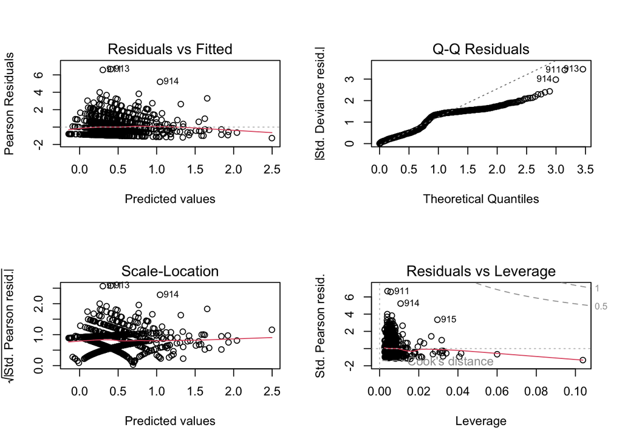

```r
# Check residuals
par(mfrow=c(2,2))
plot(model2)
```

```r
par(mfrow=c(1,1))
```

OK, some terms are significant. The negative binomial accounts for overdispersion through the theta parameter.

### Model 4: Zero-Inflated Negative Binomial (ZINB)

So, how would the zero-inflated version of this model look like?

```r
model2zi <- zeroinfl(art ~ . | ., data = bioChemists, dist = "negbin")
summary(model2zi)
```

```
##
## Call:
## zeroinfl(formula = art ~ . | ., data = bioChemists, dist = "negbin")
##
## Pearson residuals:
##     Min      1Q  Median      3Q     Max
## -1.2942 -0.7601 -0.2909  0.4448  6.4155
##
## Count model coefficients (negbin with log link):
##               Estimate Std. Error z value Pr(>|z|)
## (Intercept)  0.4167465  0.1435966   2.902  0.00371 **
## femWomen    -0.1955068  0.0755926  -2.586  0.00970 **
## marMarried   0.0975826  0.0844520   1.155  0.24789
## kid5        -0.1517325  0.0542061  -2.799  0.00512 **
## phd         -0.0007001  0.0362697  -0.019  0.98460
## ment         0.0247862  0.0034927   7.097 1.28e-12 ***
## Log(theta)   0.9763565  0.1354695   7.207 5.71e-13 ***
##
## Zero-inflation model coefficients (binomial with logit link):
##             Estimate Std. Error z value Pr(>|z|)
## (Intercept) -0.19169    1.32282  -0.145  0.88478
## femWomen     0.63593    0.84892   0.749  0.45379
## marMarried  -1.49947    0.93867  -1.597  0.11017
## kid5         0.62843    0.44278   1.419  0.15582
## phd         -0.03771    0.30801  -0.122  0.90254
## ment        -0.88229    0.31623  -2.790  0.00527 **
## ---
## Signif. codes:  0 '***' 0.001 '**' 0.01 '*' 0.05 '.' 0.1 ' ' 1
##
## Theta = 2.6548
## Number of iterations in BFGS optimization: 43
## Log-likelihood: -1550 on 13 Df
```

```r
print(paste("Theta:", round(model2zi$theta, 3)))
```

```
## [1] "Theta: 2.655"
```

The results change and we have different significant factors in this case. Thus, using the correct distribution for our data is crucial to obtain reliable results.

### Comparing All Four Models

```r
# AIC comparison
aic_values <- c(
  "Poisson" = AIC(model1),
  "ZIP" = AIC(model1zi),
  "Negative Binomial" = AIC(model2),
  "ZINB" = AIC(model2zi)
)

print("AIC values (lower is better):")
```

```
## [1] "AIC values (lower is better):"
```

```r
print(sort(aic_values))
```

```
##              ZINB Negative Binomial               ZIP           Poisson
##          3125.982          3135.917          3233.546          3314.113
```

```r
#Comparsing ZI models:
print("Model Comparison: ZIP vs Poisson")
```

```
## [1] "Model Comparison: ZIP vs Poisson"
```

```r
print(paste("Poisson AIC:", round(AIC(model1), 2)))
```

```
## [1] "Poisson AIC: 3314.11"
```

```r
print(paste("ZIP AIC:", round(AIC(model1zi), 2)))
```

```
## [1] "ZIP AIC: 3233.55"
```

```r
print(paste("AIC difference:", round(AIC(model1) - AIC(model1zi), 2)))
```

```
## [1] "AIC difference: 80.57"
```

```r
if(AIC(model1zi) < AIC(model1)) {
  print("→ Zero-inflated model is preferred (lower AIC)")
} else {
  print("→ Standard Poisson model is preferred (lower AIC)")
}
```

```
## [1] "→ Zero-inflated model is preferred (lower AIC)"
```

```r
print("")
```

```
## [1] ""
```

```r
print("Model Comparison: ZINB vs Negative Binomial")
```

```
## [1] "Model Comparison: ZINB vs Negative Binomial"
```

```r
print(paste("Negative Binomial AIC:", round(AIC(model2), 2)))
```

```
## [1] "Negative Binomial AIC: 3135.92"
```

```r
print(paste("ZINB AIC:", round(AIC(model2zi), 2)))
```

```
## [1] "ZINB AIC: 3125.98"
```

```r
print(paste("AIC difference:", round(AIC(model2) - AIC(model2zi), 2)))
```

```
## [1] "AIC difference: 9.93"
```

```r
if(AIC(model2zi) < AIC(model2)) {
  print("→ Zero-inflated model is preferred (lower AIC)")
} else {
  print("→ Standard Negative Binomial model is preferred (lower AIC)")
}
```

```
## [1] "→ Zero-inflated model is preferred (lower AIC)"
```

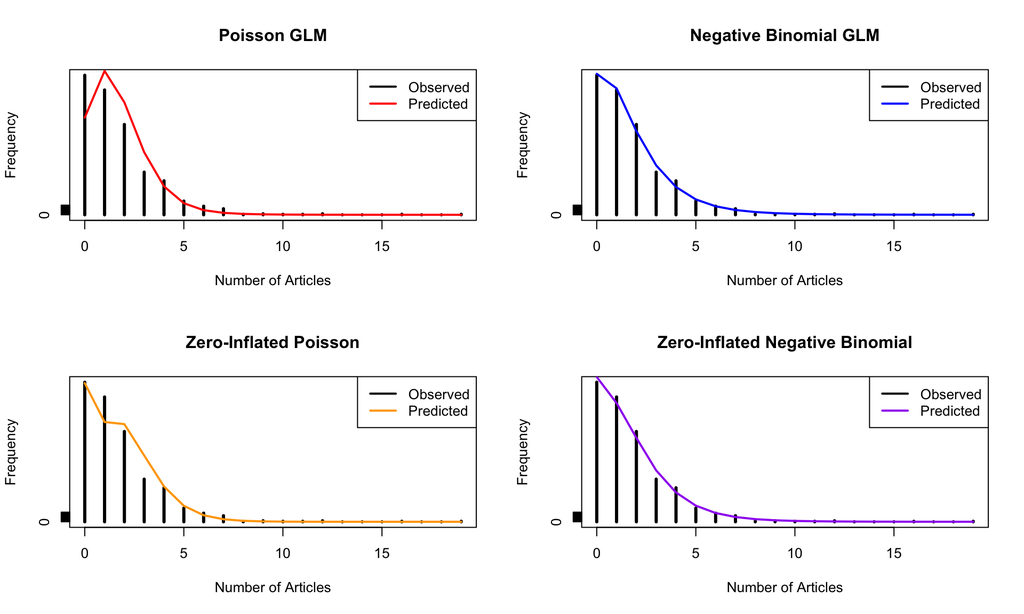

```r
# Visualize model fit
par(mfrow=c(2,2))

# Observed vs predicted for each model
obs_freq <- table(factor(bioChemists$art, levels=0:max(bioChemists$art)))

# Model 1: Poisson
max_count <- max(bioChemists$art)
pred1 <- numeric(max_count + 1)
for(i in 0:max_count) {
  pred1[i+1] <- sum(dpois(i, fitted(model1)))
}
plot(0:max(bioChemists$art), obs_freq, type="h", lwd=3, col="black",
     main="Poisson GLM", xlab="Number of Articles", ylab="Frequency")
lines(0:max(bioChemists$art), pred1, col="red", lwd=2)
legend("topright", c("Observed", "Predicted"), col=c("black", "red"), lwd=2)

# Model 2: Negative Binomial
pred2 <- numeric(max_count + 1)
for(i in 0:max_count) {
  pred2[i+1] <- sum(dnbinom(i, mu=fitted(model2), size=model2$theta))
}
plot(0:max(bioChemists$art), obs_freq, type="h", lwd=3, col="black",
     main="Negative Binomial GLM", xlab="Number of Articles", ylab="Frequency")
lines(0:max(bioChemists$art), pred2, col="blue", lwd=2)
legend("topright", c("Observed", "Predicted"), col=c("black", "blue"), lwd=2)

# Model 3: ZIP
pred1zi <- predict(model1zi, type="prob")[,1:(max(bioChemists$art)+1)]
pred1zi_freq <- colSums(pred1zi)
plot(0:max(bioChemists$art), obs_freq, type="h", lwd=3, col="black",
     main="Zero-Inflated Poisson", xlab="Number of Articles", ylab="Frequency")
lines(0:max(bioChemists$art), pred1zi_freq, col="orange", lwd=2)
legend("topright", c("Observed", "Predicted"), col=c("black", "orange"), lwd=2)

# Model 4: ZINB
pred2zi <- predict(model2zi, type="prob")[,1:(max(bioChemists$art)+1)]
pred2zi_freq <- colSums(pred2zi)
plot(0:max(bioChemists$art), obs_freq, type="h", lwd=3, col="black",
     main="Zero-Inflated Negative Binomial", xlab="Number of Articles", ylab="Frequency")
lines(0:max(bioChemists$art), pred2zi_freq, col="purple", lwd=2)
legend("topright", c("Observed", "Predicted"), col=c("black", "purple"), lwd=2)
```

```r
par(mfrow=c(1,1))
```

### Interpretation and Model Selection

```r
# Summary table
model_summary <- data.frame(
  Model = c("Poisson", "ZIP", "Neg Binomial", "ZINB"),
  AIC = round(aic_values, 1),
  Parameters = c(
    length(coef(model1)),
    length(coef(model1zi)),
    length(coef(model2)) + 1,  # +1 for theta
    length(coef(model2zi)) + 1
  )
)
model_summary$Delta_AIC <- model_summary$AIC - min(model_summary$AIC)
model_summary <- model_summary[order(model_summary$AIC),]

print("Model Selection Summary:")
```

```
## [1] "Model Selection Summary:"
```

```r
print(model_summary)
```

```
##                          Model    AIC Parameters Delta_AIC
## ZINB                      ZINB 3126.0         13       0.0
## Negative Binomial Neg Binomial 3135.9          7       9.9
## ZIP                        ZIP 3233.5         12     107.5
## Poisson                Poisson 3314.1          6     188.1
```

```r
print("")
```

```
## [1] ""
```

```r
print("Model Selection Guidelines:")
```

```
## [1] "Model Selection Guidelines:"
```

```r
print("- Delta AIC < 2: Models are essentially equivalent")
```

```
## [1] "- Delta AIC < 2: Models are essentially equivalent"
```

```r
print("- Delta AIC 2-7: Considerable support for best model")
```

```
## [1] "- Delta AIC 2-7: Considerable support for best model"
```

```r
print("- Delta AIC > 10: Best model is strongly preferred")
```

```
## [1] "- Delta AIC > 10: Best model is strongly preferred"
```

## Generalized Estimation Equations

There are many approaches to deal with non-normal data, but when our data has **correlated observations** (e.g., repeated measures, clustered data) we face additional challenges, as independence is one of the main assumptions of most statistical tests. Fortunately, there is an option to deal with correlated data: **Generalized Estimation Equations (GEE for short)**.

### Understanding GEE

**When do we need GEE?** - Repeated measurements on the same subjects over time - Clustered/grouped observations (e.g., multiple observations per site) - Spatial or temporal correlation in the data

**How GEE differs from GLM:** - **GLM:** Assumes all observations are independent - **GEE:** Accounts for correlation within clusters/subjects - **Mixed Models:** Similar purpose but different approach (random effects vs correlation structure)

**Key concept:** GEE provides **population-averaged** estimates rather than subject-specific estimates (like mixed models).

### GEE Correlation Structures

GEE models require specifying a **working correlation structure**:

1. **Independence:** No correlation (like standard GLM)
2. **Exchangeable:** All observations within a cluster equally correlated
3. **AR(1) - Autoregressive:** Correlation decreases with time/distance
4. **Unstructured:** Estimate all correlations (requires more data)

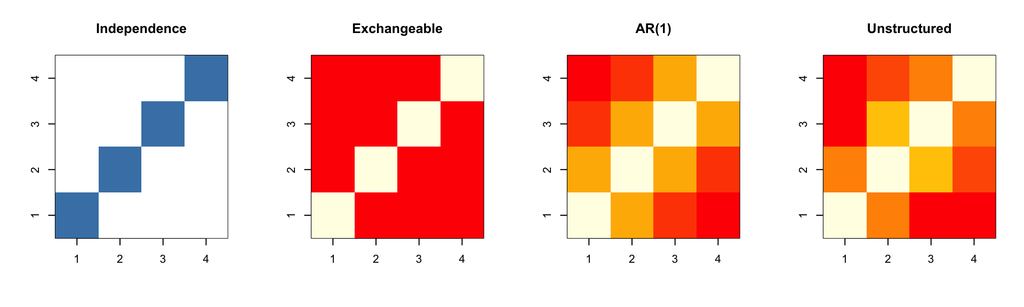

```r
# Visualize correlation structures
par(mfrow=c(1,4))

# Independence
m_ind <- matrix(c(1,0,0,0, 0,1,0,0, 0,0,1,0, 0,0,0,1), 4, 4)
image(1:4, 1:4, m_ind, main="Independence", xlab="", ylab="", col=c("white", "steelblue"))

# Exchangeable
m_exch <- matrix(c(1,0.5,0.5,0.5, 0.5,1,0.5,0.5, 0.5,0.5,1,0.5, 0.5,0.5,0.5,1), 4, 4)
image(1:4, 1:4, m_exch, main="Exchangeable", xlab="", ylab="", col=heat.colors(20))

# AR(1)
m_ar1 <- matrix(c(1,0.7,0.49,0.34, 0.7,1,0.7,0.49, 0.49,0.7,1,0.7, 0.34,0.49,0.7,1), 4, 4)
image(1:4, 1:4, m_ar1, main="AR(1)", xlab="", ylab="", col=heat.colors(20))

# Unstructured (example)
m_unstr <- matrix(c(1,0.6,0.4,0.3, 0.6,1,0.7,0.5, 0.4,0.7,1,0.6, 0.3,0.5,0.6,1), 4, 4)
image(1:4, 1:4, m_unstr, main="Unstructured", xlab="", ylab="", col=heat.colors(20))
```

```r
par(mfrow=c(1,1))
```

### Example Data: Pig Weight Gain

To illustrate this point we will use the *dietox* example data file from the `geepack` package. This dataset tracks pig weight over time under different copper supplementation treatments.

```r
data(dietox)

# Convert Cu to factor
dietox$Cu <- as.factor(dietox$Cu)

# Examine structure
str(dietox)
```

```
## 'data.frame':    861 obs. of  8 variables:
##  $ Pig   : Factor w/ 72 levels "4601","4602",..: 1 1 1 1 1 1 1 1 1 1 ...
##  $ Evit  : Factor w/ 3 levels "Evit000","Evit100",..: 1 1 1 1 1 1 1 1 1 1 ...
##  $ Cu    : Factor w/ 3 levels "Cu000","Cu035",..: 1 1 1 1 1 1 1 1 1 1 ...
##  $ Litter: Factor w/ 21 levels "1","2","3","4",..: 1 1 1 1 1 1 1 1 1 1 ...
##  $ Start : num  26.5 26.5 26.5 26.5 26.5 26.5 26.5 26.5 26.5 26.5 ...
##  $ Weight: num  26.5 27.6 36.5 40.3 49.1 ...
##  $ Feed  : num  NA 5.2 17.6 28.5 45.2 ...
##  $ Time  : int  1 2 3 4 5 6 7 8 9 10 ...
```

```r
head(dietox, 15)
```

```
##     Pig    Evit    Cu Litter    Start   Weight       Feed Time
## 1  4601 Evit000 Cu000      1 26.50000 26.50000         NA    1
## 2  4601 Evit000 Cu000      1 26.50000 27.59999   5.200005    2
## 3  4601 Evit000 Cu000      1 26.50000 36.50000  17.600000    3
## 4  4601 Evit000 Cu000      1 26.50000 40.29999  28.500000    4
## 5  4601 Evit000 Cu000      1 26.50000 49.09998  45.200001    5
## 6  4601 Evit000 Cu000      1 26.50000 55.39999  56.900002    6
## 7  4601 Evit000 Cu000      1 26.50000 59.59998  71.700005    7
## 8  4601 Evit000 Cu000      1 26.50000 67.00000  86.800001    8
## 9  4601 Evit000 Cu000      1 26.50000 76.59998 104.900002    9
## 10 4601 Evit000 Cu000      1 26.50000 86.50000 123.000000   10
## 11 4601 Evit000 Cu000      1 26.50000 91.59998 140.900002   11
## 12 4601 Evit000 Cu000      1 26.50000 98.59998 160.000000   12
## 13 4602 Evit000 Cu035      1 28.29999 28.29999         NA    1
## 14 4602 Evit000 Cu035      1 28.29999 30.09999   3.300003    2
## 15 4602 Evit000 Cu035      1 28.29999 38.29999  13.200001    3
```

```r
# Summary
print("Number of pigs:")
```

```
## [1] "Number of pigs:"
```

```r
length(unique(dietox$Pig))
```

```
## [1] 72
```

```r
print("Observations per pig:")
```

```
## [1] "Observations per pig:"
```

```r
table(table(dietox$Pig))
```

```
##
## 11 12
##  3 69
```

```r
print("Time points:")
```

```
## [1] "Time points:"
```

```r
sort(unique(dietox$Time))
```

```
##  [1]  1  2  3  4  5  6  7  8  9 10 11 12
```

### Exploratory Analysis

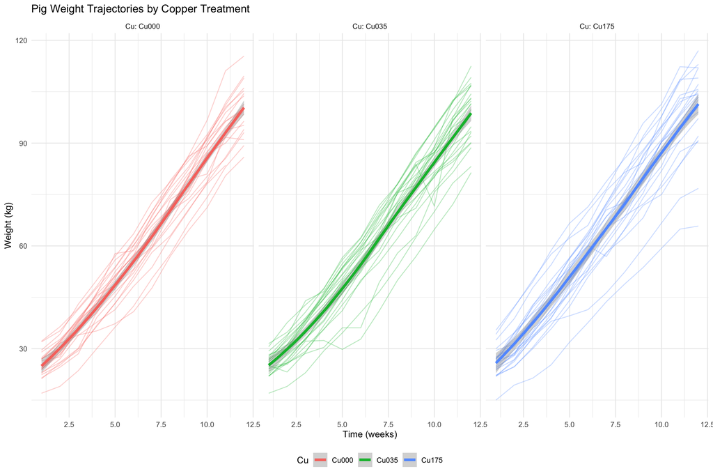

```r
# Visualize individual trajectories
ggplot(dietox, aes(x=Time, y=Weight, group=Pig, color=Cu)) +
  geom_line(alpha=0.3) +
  geom_smooth(aes(group=Cu), method="loess", se=TRUE, size=1.5) +
  facet_wrap(~Cu, labeller=label_both) +
  labs(title="Pig Weight Trajectories by Copper Treatment",
       x="Time (weeks)", y="Weight (kg)") +
  theme_minimal() +
  theme(legend.position="bottom")
```

```r
# Summary statistics by treatment and time
summary_stats <- dietox %>%
  group_by(Cu, Time) %>%
  summarise(
    n = n(),
    mean_weight = mean(Weight),
    sd_weight = sd(Weight),
    se_weight = sd(Weight)/sqrt(n()),
    .groups = 'drop'
  )

print("Summary by copper treatment and time:")
```

```
## [1] "Summary by copper treatment and time:"
```

```r
print(head(summary_stats, 12))
```

```
## # A tibble: 12 × 6
##    Cu     Time     n mean_weight sd_weight se_weight
##    <fct> <int> <int>       <dbl>     <dbl>     <dbl>
##  1 Cu000     1    23        25.3      3.50     0.730
##  2 Cu000     2    23        29.5      3.90     0.813
##  3 Cu000     3    23        35.6      4.67     0.974
##  4 Cu000     4    23        42.3      4.73     0.987
##  5 Cu000     5    23        48.7      5.66     1.18
##  6 Cu000     6    23        55.1      5.72     1.19
##  7 Cu000     7    23        62.8      6.22     1.30
##  8 Cu000     8    23        70.6      6.14     1.28
##  9 Cu000     9    23        77.8      6.02     1.25
## 10 Cu000    10    23        85.7      6.42     1.34
## 11 Cu000    11    23        93.7      7.10     1.48
## 12 Cu000    12    21        99.9      7.17     1.57
```

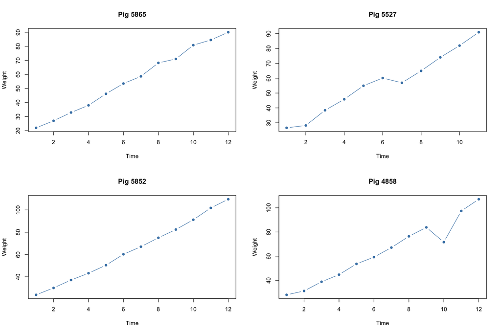

```r
# Check correlation within pigs
sample_pigs <- sample(unique(dietox$Pig), 4)
par(mfrow=c(2,2))
for(pig in sample_pigs) {
  pig_data <- dietox[dietox$Pig == pig,]
  plot(pig_data$Time, pig_data$Weight, type="b",
       main=paste("Pig", pig), xlab="Time", ylab="Weight",
       pch=16, col="steelblue")
}
```

```r
par(mfrow=c(1,1))
```

### Fitting GEE Models

GEE models allow us to indicate a correlation structure and obtain reliable estimates accounting for the repeated measures on the same pigs.

```r
# Define model formula
# Weight as polynomial function of time, with copper treatment interaction
mf <- formula(Weight ~ Cu * (Time + I(Time^2) + I(Time^3)))

# Fit GEE with AR(1) correlation structure
gee1 <- geeglm(mf, data=dietox, id=Pig, family=poisson("identity"), corstr="ar1")
summary(gee1)
```

```
##
## Call:
## geeglm(formula = mf, family = poisson("identity"), data = dietox,
##     id = Pig, corstr = "ar1")
##
##  Coefficients:
##                     Estimate    Std.err    Wald Pr(>|W|)
## (Intercept)       21.8578678  0.6931445 994.416  < 2e-16 ***
## CuCu035            0.5267337  0.9413606   0.313    0.576
## CuCu175            0.0427835  1.0196474   0.002    0.967
## Time               2.8851574  0.3602572  64.138 1.11e-15 ***
## I(Time^2)          0.6140424  0.0701643  76.589  < 2e-16 ***
## I(Time^3)         -0.0262948  0.0038218  47.338 5.98e-12 ***
## CuCu035:Time      -0.4054243  0.6371250   0.405    0.525
## CuCu175:Time       0.8569407  0.6156244   1.938    0.164
## CuCu035:I(Time^2)  0.0182863  0.1154326   0.025    0.874
## CuCu175:I(Time^2) -0.0960713  0.1107997   0.752    0.386
## CuCu035:I(Time^3)  0.0005467  0.0059896   0.008    0.927
## CuCu175:I(Time^3)  0.0026996  0.0056502   0.228    0.633
## ---
## Signif. codes:  0 '***' 0.001 '**' 0.01 '*' 0.05 '.' 0.1 ' ' 1
##
## Correlation structure = ar1
## Estimated Scale Parameters:
##
##             Estimate Std.err
## (Intercept)   0.7752  0.1416
##   Link = identity
##
## Estimated Correlation Parameters:
##       Estimate  Std.err
## alpha   0.9572 0.009788
## Number of clusters:   72  Maximum cluster size: 12
```

```r
print("Estimated correlation parameter (alpha):")
```

```
## [1] "Estimated correlation parameter (alpha):"
```

```r
print(gee1$geese$alpha)
```

```
##  alpha
## 0.9572
```

```r
print("This represents the correlation between adjacent time points")
```

```
## [1] "This represents the correlation between adjacent time points"
```

As you can see, GEE models operate in a similar way to GLM models and produce similar outputs as well.

### Comparing Different Correlation Structures

```r
# Fit models with different correlation structures
gee_ind <- geeglm(mf, data=dietox, id=Pig, family=poisson("identity"), corstr="independence")
gee_exch <- geeglm(mf, data=dietox, id=Pig, family=poisson("identity"), corstr="exchangeable")
gee_ar1 <- geeglm(mf, data=dietox, id=Pig, family=poisson("identity"), corstr="ar1")

# Compare using QIC (quasi-likelihood information criterion)
qic_values <- c(
  "Independence" = QIC(gee_ind)[1],
  "Exchangeable" = QIC(gee_exch)[1],
  "AR(1)" = QIC(gee_ar1)[1]
)

print("QIC values (lower is better):")
```

```
## [1] "QIC values (lower is better):"
```

```r
print(qic_values)
```

```
## Independence.QIC Exchangeable.QIC        AR(1).QIC
##          -333178          -333179          -333178
```

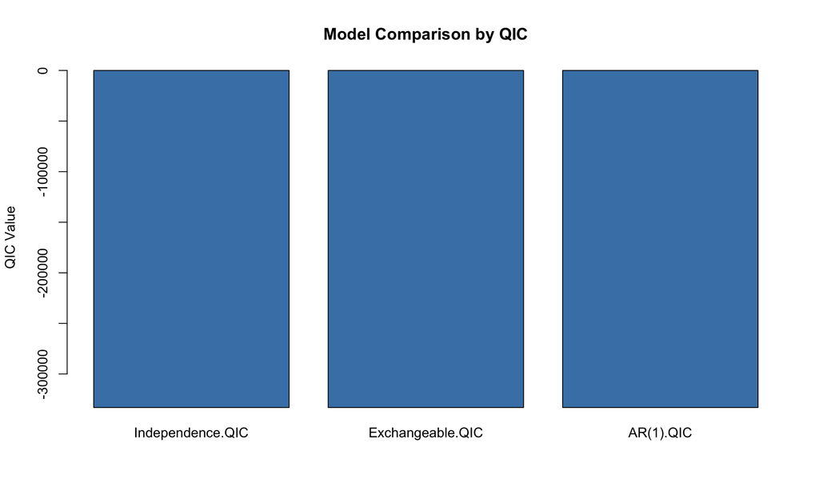

```r
barplot(qic_values, col="steelblue",
        main="Model Comparison by QIC",
        ylab="QIC Value")
```

```r
# Extract correlation parameters
print("Estimated correlation parameters:")
```

```
## [1] "Estimated correlation parameters:"
```

```r
print(paste("Exchangeable alpha:", round(gee_exch$geese$alpha, 3)))
```

```
## [1] "Exchangeable alpha: 0.841"
```

```r
print(paste("AR(1) alpha:", round(gee_ar1$geese$alpha, 3)))
```

```
## [1] "AR(1) alpha: 0.957"
```